# accumbens_and_learning

### can we explain why we’re seeing those outliers?

#### trial count

```r
trial_count = sst_all_data %>%
  filter(condition!="Cue") %>%
  group_by(subid,runid,waveid) %>%
  summarize(trial_count=n())
table(trial_count$trial_count)
```

```
##
##  128  640
## 1049    1
```

```r
time_points %>% group_by(subid, wave) %>% summarize(max_tr=max(tr)) %>% .$max_tr %>% table
```

```
## .
## 412 422
##   1 455
```

```r
#no, can't be explained by short runs. almost all subjects have the same number of trials in the behavioral data and the same number of TRs in the neural data
```

#### mean delay of the trough from the stop signal?

```r
summary(lm(mean_amplitude~mean_post_pre_rt_change,FS_by_subj %>% filter(ROI_delateralized=="Putamen")))
```

```
##
## Call:
## lm(formula = mean_amplitude ~ mean_post_pre_rt_change, data = FS_by_subj %>%
##     filter(ROI_delateralized == "Putamen"))
##
## Residuals:
##      Min       1Q   Median       3Q      Max
## -0.33539 -0.13275 -0.02998  0.06538  1.55193
##
## Coefficients:
##                         Estimate Std. Error t value Pr(>|t|)
## (Intercept)              0.51899    0.02133  24.328  < 2e-16 ***
## mean_post_pre_rt_change  1.03947    0.30358   3.424 0.000724 ***
## ---
## Signif. codes:  0 '***' 0.001 '**' 0.01 '*' 0.05 '.' 0.1 ' ' 1
##
## Residual standard error: 0.2144 on 242 degrees of freedom
## Multiple R-squared:  0.04621,    Adjusted R-squared:  0.04227
## F-statistic: 11.72 on 1 and 242 DF,  p-value: 0.0007244
```

```r
summary(lm(mean_amplitude~mean_post_pre_rt_change+mean_trough_offset,FS_by_subj %>% filter(ROI_delateralized=="Putamen")))
```

```
##
## Call:
## lm(formula = mean_amplitude ~ mean_post_pre_rt_change + mean_trough_offset,
##     data = FS_by_subj %>% filter(ROI_delateralized == "Putamen"))
##
## Residuals:
##      Min       1Q   Median       3Q      Max
## -0.39053 -0.11610 -0.03271  0.07734  1.41759
##
## Coefficients:
##                         Estimate Std. Error t value Pr(>|t|)
## (Intercept)              1.01262    0.10327   9.805  < 2e-16 ***
## mean_post_pre_rt_change  1.03374    0.29023   3.562 0.000444 ***
## mean_trough_offset      -0.20611    0.04227  -4.876 1.97e-06 ***
## ---
## Signif. codes:  0 '***' 0.001 '**' 0.01 '*' 0.05 '.' 0.1 ' ' 1
##
## Residual standard error: 0.205 on 241 degrees of freedom
## Multiple R-squared:  0.1319, Adjusted R-squared:  0.1246
## F-statistic:  18.3 on 2 and 241 DF,  p-value: 3.987e-08
```

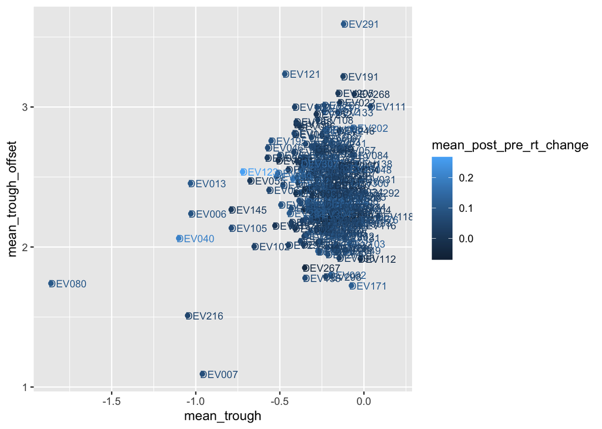

```r
ggplot(FS_by_subj %>% filter(ROI_delateralized=="Putamen"),
       aes(x=mean_trough,y=mean_trough_offset,
           label=subid,color=mean_post_pre_rt_change))+geom_point(binwidth=0.2)+geom_text(size=3,nudge_x=0.1)
```

```r
  labs(title="Across-subject correlation of subject-mean Putamen amplitude\nby subject-mean post-pre RT change")
```

```
## $title
## [1] "Across-subject correlation of subject-mean Putamen amplitude\nby subject-mean post-pre RT change"
##
## attr(,"class")
## [1] "labels"
```

That’s interesting, but it doesn’t really explain away the amplitude by RT change relationship.

#### What about subject SSD?

Due to the ladder, the shorter the mean SSD, the btter that participant has performed.

```r
summary(lm(mean_amplitude~mean_post_pre_rt_change,FS_by_subj %>% filter(ROI_delateralized=="Putamen")))
```

```
##
## Call:
## lm(formula = mean_amplitude ~ mean_post_pre_rt_change, data = FS_by_subj %>%
##     filter(ROI_delateralized == "Putamen"))
##
## Residuals:
##      Min       1Q   Median       3Q      Max
## -0.33539 -0.13275 -0.02998  0.06538  1.55193
##
## Coefficients:
##                         Estimate Std. Error t value Pr(>|t|)
## (Intercept)              0.51899    0.02133  24.328  < 2e-16 ***
## mean_post_pre_rt_change  1.03947    0.30358   3.424 0.000724 ***
## ---
## Signif. codes:  0 '***' 0.001 '**' 0.01 '*' 0.05 '.' 0.1 ' ' 1
##
## Residual standard error: 0.2144 on 242 degrees of freedom
## Multiple R-squared:  0.04621,    Adjusted R-squared:  0.04227
## F-statistic: 11.72 on 1 and 242 DF,  p-value: 0.0007244
```

```r
summary(lm(mean_amplitude~mean_post_pre_rt_change+mean_SSD_all_stop_trials,FS_by_subj %>% filter(ROI_delateralized=="Putamen")))
```

```
##
## Call:
## lm(formula = mean_amplitude ~ mean_post_pre_rt_change + mean_SSD_all_stop_trials,
##     data = FS_by_subj %>% filter(ROI_delateralized == "Putamen"))
##
## Residuals:
##      Min       1Q   Median       3Q      Max
## -0.33537 -0.13310 -0.03004  0.06513  1.55101
##
## Coefficients:
##                          Estimate Std. Error t value Pr(>|t|)
## (Intercept)              0.517966   0.038737  13.371  < 2e-16 ***
## mean_post_pre_rt_change  1.038069   0.307402   3.377 0.000855 ***
## mean_SSD_all_stop_trials 0.004374   0.137698   0.032 0.974685
## ---
## Signif. codes:  0 '***' 0.001 '**' 0.01 '*' 0.05 '.' 0.1 ' ' 1
##
## Residual standard error: 0.2149 on 241 degrees of freedom
## Multiple R-squared:  0.04621,    Adjusted R-squared:  0.0383
## F-statistic: 5.838 on 2 and 241 DF,  p-value: 0.003341
```

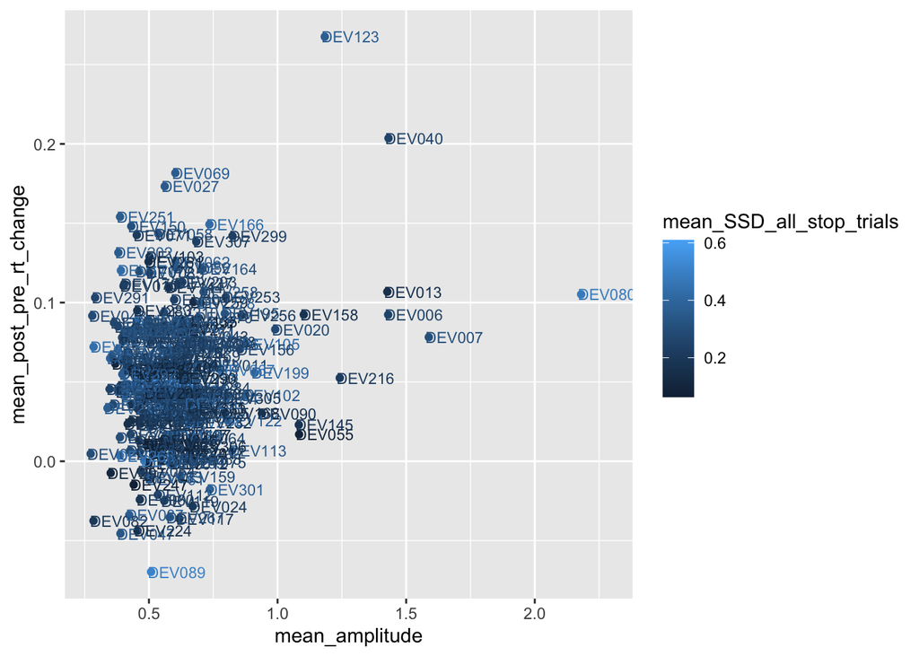

```r
ggplot(FS_by_subj %>% filter(ROI_delateralized=="Putamen"),
       aes(x=mean_amplitude,y=mean_post_pre_rt_change,
           label=subid,color=mean_SSD_all_stop_trials))+geom_point(binwidth=0.2)+geom_text(size=3,nudge_x=0.1)
```

```r
  labs(title="Across-subject correlation of subject-mean Putamen amplitude\nby subject-mean post-pre RT change")
```

```
## $title
## [1] "Across-subject correlation of subject-mean Putamen amplitude\nby subject-mean post-pre RT change"
##
## attr(,"class")
## [1] "labels"
```

```r
#not related to performance!
```

## Modeling effects

If we do a multi-level model, with response amplitude as a within-group slope, we need to be able to measure whether the estimate of that within-group slope differs from zero. If we add it as a random effect, I don’t think we can do that…?

```r
library(lme4)
#FS_neural_behav_data_not_na$trial_n_c<-128-FS_neural_behav_data_not_na$trial_n
FS_neural_behav_p <- FS_neural_behav_data_not_na %>% filter(ROI_delateralized=="Putamen")

model_random_effects <- lme4::lmer(
   post_pre_rt_change ~ trial_n_c +I(trial_n_c^2) + response_amplitude + (1+ response_amplitude | subid),
  FS_neural_behav_p
  )
```

```
## boundary (singular) fit: see help('isSingular')
```

```r
summary(model_random_effects)
```

```
## Linear mixed model fit by REML ['lmerMod']
## Formula:
## post_pre_rt_change ~ trial_n_c + I(trial_n_c^2) + response_amplitude +
##     (1 + response_amplitude | subid)
##    Data: FS_neural_behav_p
##
## REML criterion at convergence: -4389.7
##
## Scaled residuals:
##     Min      1Q  Median      3Q     Max
## -4.0910 -0.5611 -0.0363  0.5537  3.7912
##
## Random effects:
##  Groups   Name               Variance  Std.Dev. Corr
##  subid    (Intercept)        0.0000000 0.00000
##           response_amplitude 0.0007241 0.02691   NaN
##  Residual                    0.0231030 0.15200
## Number of obs: 4862, groups:  subid, 244
##
## Fixed effects:
##                      Estimate Std. Error t value
## (Intercept)         5.618e-02  4.459e-03  12.600
## trial_n_c          -1.672e-04  2.786e-05  -6.001
## I(trial_n_c^2)     -6.800e-07  4.278e-07  -1.589
## response_amplitude -1.106e-03  5.197e-03  -0.213
##
## Correlation of Fixed Effects:
##             (Intr) trl_n_ I(__^2
## trial_n_c   -0.006
## I(trl_n_^2) -0.628 -0.135
## rspns_mpltd -0.566  0.000  0.014
## fit warnings:
## Some predictor variables are on very different scales: consider rescaling
## optimizer (nloptwrap) convergence code: 0 (OK)
## boundary (singular) fit: see help('isSingular')
```

```r
model_fixed_effects <- lme4::lmer(
   post_pre_rt_change ~ trial_n_c +I(trial_n_c^2) + response_amplitude + (1 | subid),
  FS_neural_behav_p
  )
summary(model_fixed_effects)
```

```
## Linear mixed model fit by REML ['lmerMod']
## Formula:
## post_pre_rt_change ~ trial_n_c + I(trial_n_c^2) + response_amplitude +
##     (1 | subid)
##    Data: FS_neural_behav_p
##
## REML criterion at convergence: -4404.4
##
## Scaled residuals:
##     Min      1Q  Median      3Q     Max
## -4.0852 -0.5573 -0.0292  0.5518  3.8340
##
## Random effects:
##  Groups   Name        Variance  Std.Dev.
##  subid    (Intercept) 0.0006141 0.02478
##  Residual             0.0228853 0.15128
## Number of obs: 4862, groups:  subid, 244
##
## Fixed effects:
##                      Estimate Std. Error t value
## (Intercept)         5.530e-02  4.581e-03  12.072
## trial_n_c          -1.753e-04  2.776e-05  -6.314
## I(trial_n_c^2)     -6.783e-07  4.275e-07  -1.587
## response_amplitude  3.479e-03  3.996e-03   0.871
##
## Correlation of Fixed Effects:
##             (Intr) trl_n_ I(__^2
## trial_n_c   -0.017
## I(trl_n_^2) -0.617 -0.133
## rspns_mpltd -0.511  0.018  0.020
## fit warnings:
## Some predictor variables are on very different scales: consider rescaling
```

If the random effects model is more predictive than the fixed effects model, we have significant random effects, too.

```r
anova(model_fixed_effects,model_random_effects)
```

```
## refitting model(s) with ML (instead of REML)
```

```
## Data: FS_neural_behav_p
## Models:
## model_fixed_effects: post_pre_rt_change ~ trial_n_c + I(trial_n_c^2) + response_amplitude + (1 | subid)
## model_random_effects: post_pre_rt_change ~ trial_n_c + I(trial_n_c^2) + response_amplitude + (1 + response_amplitude | subid)
##                      npar     AIC     BIC logLik deviance Chisq Df Pr(>Chisq)
## model_fixed_effects     6 -4458.2 -4419.3 2235.1  -4470.2
## model_random_effects    8 -4439.3 -4387.4 2227.7  -4455.3     0  2          1
```

OK, that’s discouraging. So we can’t show that the random effects model performs superior to the fixed effects model.

```r
model_random_only <- lme4::lmer(
   post_pre_rt_change ~ trial_n_c +I(trial_n_c^2) + (1 + response_amplitude | subid),
  FS_neural_behav_p
  )
```

```
## boundary (singular) fit: see help('isSingular')
```

```r
summary(model_random_only)
```

```
## Linear mixed model fit by REML ['lmerMod']
## Formula:
## post_pre_rt_change ~ trial_n_c + I(trial_n_c^2) + (1 + response_amplitude |
##     subid)
##    Data: FS_neural_behav_p
##
## REML criterion at convergence: -4398.4
##
## Scaled residuals:
##     Min      1Q  Median      3Q     Max
## -4.0923 -0.5601 -0.0362  0.5540  3.7859
##
## Random effects:
##  Groups   Name               Variance  Std.Dev. Corr
##  subid    (Intercept)        0.0000000 0.00000
##           response_amplitude 0.0006998 0.02645   NaN
##  Residual                    0.0231074 0.15201
## Number of obs: 4862, groups:  subid, 244
##
## Fixed effects:
##                  Estimate Std. Error t value
## (Intercept)     5.561e-02  3.672e-03  15.142
## trial_n_c      -1.671e-04  2.786e-05  -5.998
## I(trial_n_c^2) -6.778e-07  4.278e-07  -1.584
##
## Correlation of Fixed Effects:
##             (Intr) trl_n_
## trial_n_c   -0.008
## I(trl_n_^2) -0.753 -0.135
## fit warnings:
## Some predictor variables are on very different scales: consider rescaling
## optimizer (nloptwrap) convergence code: 0 (OK)
## boundary (singular) fit: see help('isSingular')
```

```r
anova(model_random_only,model_random_effects)
```

```
## refitting model(s) with ML (instead of REML)
```

```
## Data: FS_neural_behav_p
## Models:
## model_random_only: post_pre_rt_change ~ trial_n_c + I(trial_n_c^2) + (1 + response_amplitude | subid)
## model_random_effects: post_pre_rt_change ~ trial_n_c + I(trial_n_c^2) + response_amplitude + (1 + response_amplitude | subid)
##                      npar     AIC     BIC logLik deviance  Chisq Df Pr(>Chisq)
## model_random_only       7 -4441.3 -4395.8 2227.6  -4455.3
## model_random_effects    8 -4439.3 -4387.4 2227.7  -4455.3 0.0392  1     0.8431
```

### Include trough offset

```r
library(lme4)
#FS_neural_behav_data_not_na$trial_n_c<-128-FS_neural_behav_data_not_na$trial_n
FS_neural_behav_p <- FS_neural_behav_data_not_na %>% filter(ROI_delateralized=="Putamen")

model_random_effects <- lme4::lmer(
   post_pre_rt_change ~ trial_n_c +I(trial_n_c^2) + response_amplitude +trough_time + (1+ response_amplitude+ trough_time | subid),
  FS_neural_behav_p
  )
```

```
## boundary (singular) fit: see help('isSingular')
```

```r
summary(model_random_effects)
```

```
## Linear mixed model fit by REML ['lmerMod']
## Formula:
## post_pre_rt_change ~ trial_n_c + I(trial_n_c^2) + response_amplitude +
##     trough_time + (1 + response_amplitude + trough_time | subid)
##    Data: FS_neural_behav_p
##
## REML criterion at convergence: -4396
##
## Scaled residuals:
##     Min      1Q  Median      3Q     Max
## -4.0619 -0.5596 -0.0326  0.5524  3.8073
##
## Random effects:
##  Groups   Name               Variance  Std.Dev. Corr
##  subid    (Intercept)        4.915e-04 0.022171
##           response_amplitude 8.685e-05 0.009319  1.00
##           trough_time        3.060e-05 0.005532 -0.43 -0.43
##  Residual                    2.282e-02 0.151054
## Number of obs: 4862, groups:  subid, 244
##
## Fixed effects:
##                      Estimate Std. Error t value
## (Intercept)         5.866e-02  6.764e-03   8.672
## trial_n_c          -1.742e-04  2.776e-05  -6.274
## I(trial_n_c^2)     -6.919e-07  4.273e-07  -1.619
## response_amplitude  1.347e-03  4.358e-03   0.309
## trough_time        -8.876e-04  1.945e-03  -0.456
##
## Correlation of Fixed Effects:
##             (Intr) trl_n_ I(__^2 rspns_
## trial_n_c   -0.002
## I(trl_n_^2) -0.411 -0.133
## rspns_mpltd -0.450  0.010  0.016
## trough_time -0.742 -0.011 -0.007  0.162
## fit warnings:
## Some predictor variables are on very different scales: consider rescaling
## optimizer (nloptwrap) convergence code: 0 (OK)
## boundary (singular) fit: see help('isSingular')
```

```r
model_fixed_effects <- lme4::lmer(
   post_pre_rt_change ~ trial_n_c +I(trial_n_c^2) + response_amplitude+trough_time + (1 | subid),
  FS_neural_behav_p
  )
summary(model_fixed_effects)
```

```
## Linear mixed model fit by REML ['lmerMod']
## Formula:
## post_pre_rt_change ~ trial_n_c + I(trial_n_c^2) + response_amplitude +
##     trough_time + (1 | subid)
##    Data: FS_neural_behav_p
##
## REML criterion at convergence: -4393.8
##
## Scaled residuals:
##     Min      1Q  Median      3Q     Max
## -4.0782 -0.5591 -0.0279  0.5521  3.8231
##
## Random effects:
##  Groups   Name        Variance  Std.Dev.
##  subid    (Intercept) 0.0006141 0.02478
##  Residual             0.0228894 0.15129
## Number of obs: 4862, groups:  subid, 244
##
## Fixed effects:
##                      Estimate Std. Error t value
## (Intercept)         5.717e-02  6.724e-03   8.503
## trial_n_c          -1.752e-04  2.776e-05  -6.310
## I(trial_n_c^2)     -6.771e-07  4.276e-07  -1.584
## response_amplitude  3.216e-03  4.056e-03   0.793
## trough_time        -7.234e-04  1.900e-03  -0.381
##
## Correlation of Fixed Effects:
##             (Intr) trl_n_ I(__^2 rspns_
## trial_n_c   -0.005
## I(trl_n_^2) -0.415 -0.133
## rspns_mpltd -0.468  0.016  0.018
## trough_time -0.732 -0.010 -0.007  0.171
## fit warnings:
## Some predictor variables are on very different scales: consider rescaling
```

```r
anova(model_fixed_effects,model_random_effects)
```

```
## refitting model(s) with ML (instead of REML)
```

```
## Data: FS_neural_behav_p
## Models:
## model_fixed_effects: post_pre_rt_change ~ trial_n_c + I(trial_n_c^2) + response_amplitude + trough_time + (1 | subid)
## model_random_effects: post_pre_rt_change ~ trial_n_c + I(trial_n_c^2) + response_amplitude + trough_time + (1 + response_amplitude + trough_time | subid)
##                      npar     AIC     BIC logLik deviance  Chisq Df Pr(>Chisq)
## model_fixed_effects     7 -4456.4 -4410.9 2235.2  -4470.4
## model_random_effects   12 -4448.3 -4370.5 2236.2  -4472.3 1.9886  5     0.8507
```

# Exploring different behavioral componetns of the measure

## First repeat the analysis above, but modeling brain activity rather than behavioral activity

```r
FS_neural_behav_data_not_na$trial_n_c<-128-FS_neural_behav_data_not_na$trial_n

library(lme4)

FS_neural_behav_p <- FS_neural_behav_data_not_na %>% filter(ROI_delateralized=="Putamen")

model_random_effects <- lme4::lmer(
   response_amplitude ~ trial_n_c +I(trial_n_c^2) + post_pre_rt_change + (1+ post_pre_rt_change | subid),
  FS_neural_behav_p
  )
summary(model_random_effects)
```

```
## Linear mixed model fit by REML ['lmerMod']
## Formula:
## response_amplitude ~ trial_n_c + I(trial_n_c^2) + post_pre_rt_change +
##     (1 + post_pre_rt_change | subid)
##    Data: FS_neural_behav_p
##
## REML criterion at convergence: 7960
##
## Scaled residuals:
##     Min      1Q  Median      3Q     Max
## -3.3148 -0.5091 -0.1569  0.2853 14.8939
##
## Random effects:
##  Groups   Name               Variance Std.Dev. Corr
##  subid    (Intercept)        0.01325  0.1151
##           post_pre_rt_change 0.32388  0.5691   0.55
##  Residual                    0.28217  0.5312
## Number of obs: 4862, groups:  subid, 244
##
## Fixed effects:
##                      Estimate Std. Error t value
## (Intercept)         5.824e-01  1.509e-02  38.592
## trial_n_c          -1.180e-04  9.900e-05  -1.192
## I(trial_n_c^2)     -1.995e-06  1.516e-06  -1.316
## post_pre_rt_change  5.212e-02  6.435e-02   0.810
##
## Correlation of Fixed Effects:
##             (Intr) trl_n_ I(__^2
## trial_n_c   -0.026
## I(trl_n_^2) -0.660 -0.132
## pst_pr_rt_c  0.001  0.072  0.019
## fit warnings:
## Some predictor variables are on very different scales: consider rescaling
```

```r
model_fixed_effects <- lme4::lmer(
   response_amplitude ~ trial_n_c +I(trial_n_c^2)+ post_pre_rt_change + (1 | subid),
  FS_neural_behav_p
  )
summary(model_fixed_effects)
```

```
## Linear mixed model fit by REML ['lmerMod']
## Formula:
## response_amplitude ~ trial_n_c + I(trial_n_c^2) + post_pre_rt_change +
##     (1 | subid)
##    Data: FS_neural_behav_p
##
## REML criterion at convergence: 7997.2
##
## Scaled residuals:
##     Min      1Q  Median      3Q     Max
## -1.8862 -0.5078 -0.1625  0.2836 16.4340
##
## Random effects:
##  Groups   Name        Variance Std.Dev.
##  subid    (Intercept) 0.01776  0.1333
##  Residual             0.28896  0.5375
## Number of obs: 4862, groups:  subid, 244
##
## Fixed effects:
##                      Estimate Std. Error t value
## (Intercept)         5.847e-01  1.586e-02  36.873
## trial_n_c          -1.231e-04  9.954e-05  -1.237
## I(trial_n_c^2)     -2.080e-06  1.529e-06  -1.360
## post_pre_rt_change  3.654e-02  5.136e-02   0.711
##
## Correlation of Fixed Effects:
##             (Intr) trl_n_ I(__^2
## trial_n_c   -0.028
## I(trl_n_^2) -0.636 -0.130
## pst_pr_rt_c -0.190  0.093  0.024
## fit warnings:
## Some predictor variables are on very different scales: consider rescaling
```

```r
anova(model_fixed_effects,model_random_effects)
```

```
## refitting model(s) with ML (instead of REML)
```

```
## Data: FS_neural_behav_p
## Models:
## model_fixed_effects: response_amplitude ~ trial_n_c + I(trial_n_c^2) + post_pre_rt_change + (1 | subid)
## model_random_effects: response_amplitude ~ trial_n_c + I(trial_n_c^2) + post_pre_rt_change + (1 + post_pre_rt_change | subid)
##                      npar    AIC    BIC  logLik deviance  Chisq Df Pr(>Chisq)
## model_fixed_effects     6 7956.5 7995.4 -3972.2   7944.5
## model_random_effects    8 7923.6 7975.5 -3953.8   7907.6 36.842  2  9.995e-09
##
## model_fixed_effects
## model_random_effects ***
## ---
## Signif. codes:  0 '***' 0.001 '**' 0.01 '*' 0.05 '.' 0.1 ' ' 1
```

OK, how on earth do I interpret that? Quite possibly just that trial_n_c is functioning differently here.

## repeat without the quadratic trial count because it no longer seems to be helping.

```r
FS_neural_behav_data_not_na$trial_n_c<-128-FS_neural_behav_data_not_na$trial_n

library(lme4)

FS_neural_behav_p <- FS_neural_behav_data_not_na %>% filter(ROI_delateralized=="Putamen")

model_random_effects <- lme4::lmer(
   response_amplitude ~ trial_n_c+ post_pre_rt_change + (1+ post_pre_rt_change | subid),
  FS_neural_behav_p
  )
summary(model_random_effects)
```

```
## Linear mixed model fit by REML ['lmerMod']
## Formula:
## response_amplitude ~ trial_n_c + post_pre_rt_change + (1 + post_pre_rt_change |
##     subid)
##    Data: FS_neural_behav_p
##
## REML criterion at convergence: 7936.8
##
## Scaled residuals:
##     Min      1Q  Median      3Q     Max
## -3.3220 -0.5106 -0.1565  0.2869 14.8708
##
## Random effects:
##  Groups   Name               Variance Std.Dev. Corr
##  subid    (Intercept)        0.01325  0.1151
##           post_pre_rt_change 0.32426  0.5694   0.55
##  Residual                    0.28221  0.5312
## Number of obs: 4862, groups:  subid, 244
##
## Fixed effects:
##                      Estimate Std. Error t value
## (Intercept)         5.693e-01  1.134e-02  50.215
## trial_n_c          -1.351e-04  9.815e-05  -1.377
## post_pre_rt_change  5.372e-02  6.436e-02   0.835
##
## Correlation of Fixed Effects:
##             (Intr) trl_n_
## trial_n_c   -0.151
## pst_pr_rt_c  0.019  0.075
```

```r
model_fixed_effects <- lme4::lmer(
   response_amplitude ~ trial_n_c+ post_pre_rt_change + (1 | subid),
  FS_neural_behav_p
  )
summary(model_fixed_effects)
```

```
## Linear mixed model fit by REML ['lmerMod']
## Formula: response_amplitude ~ trial_n_c + post_pre_rt_change + (1 | subid)
##    Data: FS_neural_behav_p
##
## REML criterion at convergence: 7974.1
##
## Scaled residuals:
##     Min      1Q  Median      3Q     Max
## -1.8667 -0.5075 -0.1620  0.2824 16.4136
##
## Random effects:
##  Groups   Name        Variance Std.Dev.
##  subid    (Intercept) 0.01778  0.1333
##  Residual             0.28900  0.5376
## Number of obs: 4862, groups:  subid, 244
##
## Fixed effects:
##                      Estimate Std. Error t value
## (Intercept)         0.5709888  0.0122473  46.622
## trial_n_c          -0.0001408  0.0000987  -1.426
## post_pre_rt_change  0.0381733  0.0513454   0.743
##
## Correlation of Fixed Effects:
##             (Intr) trl_n_
## trial_n_c   -0.144
## pst_pr_rt_c -0.227  0.097
```

```r
anova(model_fixed_effects,model_random_effects)
```

```
## refitting model(s) with ML (instead of REML)
```

```
## Data: FS_neural_behav_p
## Models:
## model_fixed_effects: response_amplitude ~ trial_n_c + post_pre_rt_change + (1 | subid)
## model_random_effects: response_amplitude ~ trial_n_c + post_pre_rt_change + (1 + post_pre_rt_change | subid)
##                      npar    AIC    BIC  logLik deviance  Chisq Df Pr(>Chisq)
## model_fixed_effects     5 7956.3 7988.8 -3973.2   7946.3
## model_random_effects    7 7923.4 7968.8 -3954.7   7909.4 36.962  2  9.415e-09
##
## model_fixed_effects
## model_random_effects ***
## ---
## Signif. codes:  0 '***' 0.001 '**' 0.01 '*' 0.05 '.' 0.1 ' ' 1
```

## Now separate out post and previous RT

```r
#FS_neural_behav_data_not_na$trial_n_c<-128-FS_neural_behav_data_not_na$trial_n

library(lme4)

#FS_neural_behav_p <- FS_neural_behav_data_not_na %>% filter(ROI_delateralized=="Putamen")


model_random_effects <- lme4::lmer(
   response_amplitude ~ trial_n_c + last_reaction_time+ next_reaction_time + (1+ last_reaction_time+ next_reaction_time | subid),
  FS_neural_behav_p
  )
summary(model_random_effects)
```

```
## Linear mixed model fit by REML ['lmerMod']
## Formula:
## response_amplitude ~ trial_n_c + last_reaction_time + next_reaction_time +
##     (1 + last_reaction_time + next_reaction_time | subid)
##    Data: FS_neural_behav_p
##
## REML criterion at convergence: 7527.9
##
## Scaled residuals:
##     Min      1Q  Median      3Q     Max
## -3.7920 -0.5119 -0.1536  0.2959 14.5099
##
## Random effects:
##  Groups   Name               Variance Std.Dev. Corr
##  subid    (Intercept)        0.1233   0.3511
##           last_reaction_time 0.1260   0.3550    0.21
##           next_reaction_time 0.6971   0.8349   -0.76 -0.79
##  Residual                    0.2696   0.5192
## Number of obs: 4710, groups:  subid, 244
##
## Fixed effects:
##                      Estimate Std. Error t value
## (Intercept)         0.5642067  0.0517789  10.896
## trial_n_c          -0.0001869  0.0001018  -1.837
## last_reaction_time -0.0463993  0.0741877  -0.625
## next_reaction_time  0.0668280  0.0843365   0.792
##
## Correlation of Fixed Effects:
##             (Intr) trl_n_ lst_r_
## trial_n_c   -0.152
## lst_rctn_tm -0.485  0.011
## nxt_rctn_tm -0.630  0.119 -0.340
```

```r
model_fixed_effects <- lme4::lmer(
   response_amplitude ~ trial_n_c + last_reaction_time+ next_reaction_time + (1 | subid),
  FS_neural_behav_p
  )
summary(model_fixed_effects)
```

```
## Linear mixed model fit by REML ['lmerMod']
## Formula:
## response_amplitude ~ trial_n_c + last_reaction_time + next_reaction_time +
##     (1 | subid)
##    Data: FS_neural_behav_p
##
## REML criterion at convergence: 7587.9
##
## Scaled residuals:
##     Min      1Q  Median      3Q     Max
## -1.9502 -0.5080 -0.1596  0.2892 16.6321
##
## Random effects:
##  Groups   Name        Variance Std.Dev.
##  subid    (Intercept) 0.01937  0.1392
##  Residual             0.27954  0.5287
## Number of obs: 4710, groups:  subid, 244
##
## Fixed effects:
##                      Estimate Std. Error t value
## (Intercept)         0.5600340  0.0481293  11.636
## trial_n_c          -0.0001963  0.0001025  -1.915
## last_reaction_time -0.0311596  0.0706291  -0.441
## next_reaction_time  0.0620387  0.0634960   0.977
##
## Correlation of Fixed Effects:
##             (Intr) trl_n_ lst_r_
## trial_n_c   -0.167
## lst_rctn_tm -0.610  0.012
## nxt_rctn_tm -0.599  0.159 -0.219
```

```r
anova(model_fixed_effects,model_random_effects)
```

```
## refitting model(s) with ML (instead of REML)
```

```
## Data: FS_neural_behav_p
## Models:
## model_fixed_effects: response_amplitude ~ trial_n_c + last_reaction_time + next_reaction_time + (1 | subid)
## model_random_effects: response_amplitude ~ trial_n_c + last_reaction_time + next_reaction_time + (1 + last_reaction_time + next_reaction_time | subid)
##                      npar    AIC    BIC  logLik deviance  Chisq Df Pr(>Chisq)
## model_fixed_effects     6 7569.2 7607.9 -3778.6   7557.2
## model_random_effects   11 7519.7 7590.7 -3748.8   7497.7 59.514  5  1.532e-11
##
## model_fixed_effects
## model_random_effects ***
## ---
## Signif. codes:  0 '***' 0.001 '**' 0.01 '*' 0.05 '.' 0.1 ' ' 1
```

```r
#FS_neural_behav_data_not_na$trial_n_c<-128-FS_neural_behav_data_not_na$trial_n

library(lme4)



model_random_effects <- lme4::lmer(
   response_amplitude ~ trial_n_c + last_reaction_time+ next_reaction_time + reaction_time+ (1+ last_reaction_time+ next_reaction_time | subid),
  FS_neural_behav_p
  )
```

```
## boundary (singular) fit: see help('isSingular')
```

```r
summary(model_random_effects)
```

```
## Linear mixed model fit by REML ['lmerMod']
## Formula:
## response_amplitude ~ trial_n_c + last_reaction_time + next_reaction_time +
##     reaction_time + (1 + last_reaction_time + next_reaction_time |      subid)
##    Data: FS_neural_behav_p
##
## REML criterion at convergence: 7547.4
##
## Scaled residuals:
##     Min      1Q  Median      3Q     Max
## -3.4114 -0.5078 -0.1610  0.2913 14.8777
##
## Random effects:
##  Groups   Name               Variance Std.Dev. Corr
##  subid    (Intercept)        0.0000   0.0000
##           last_reaction_time 0.2545   0.5045     NaN
##           next_reaction_time 0.3901   0.6246     NaN -0.95
##  Residual                    0.2727   0.5222
## Number of obs: 4710, groups:  subid, 244
##
## Fixed effects:
##                      Estimate Std. Error t value
## (Intercept)         0.5092502  0.0505516  10.074
## trial_n_c          -0.0001868  0.0001017  -1.837
## last_reaction_time -0.1023886  0.0804792  -1.272
## next_reaction_time  0.0054687  0.0792199   0.069
## reaction_time       0.2397523  0.0852501   2.812
##
## Correlation of Fixed Effects:
##             (Intr) trl_n_ lst_r_ nxt_r_
## trial_n_c   -0.151
## lst_rctn_tm -0.406  0.012
## nxt_rctn_tm -0.323  0.126 -0.324
## reaction_tm -0.411 -0.006 -0.212 -0.279
## optimizer (nloptwrap) convergence code: 0 (OK)
## boundary (singular) fit: see help('isSingular')
```

```r
model_fixed_effects <- lme4::lmer(
   response_amplitude ~ trial_n_c + last_reaction_time+ next_reaction_time + reaction_time+ (1 | subid),
  FS_neural_behav_p
  )
summary(model_fixed_effects)
```

```
## Linear mixed model fit by REML ['lmerMod']
## Formula:
## response_amplitude ~ trial_n_c + last_reaction_time + next_reaction_time +
##     reaction_time + (1 | subid)
##    Data: FS_neural_behav_p
##
## REML criterion at convergence: 7582.4
##
## Scaled residuals:
##     Min      1Q  Median      3Q     Max
## -1.9219 -0.5121 -0.1597  0.2939 16.7050
##
## Random effects:
##  Groups   Name        Variance Std.Dev.
##  subid    (Intercept) 0.01944  0.1394
##  Residual             0.27905  0.5283
## Number of obs: 4710, groups:  subid, 244
##
## Fixed effects:
##                      Estimate Std. Error t value
## (Intercept)         0.4981860  0.0525240   9.485
## trial_n_c          -0.0001987  0.0001024  -1.940
## last_reaction_time -0.0813750  0.0726265  -1.120
## next_reaction_time -0.0025530  0.0671524  -0.038
## reaction_time       0.2514077  0.0856611   2.935
##
## Correlation of Fixed Effects:
##             (Intr) trl_n_ lst_r_ nxt_r_
## trial_n_c   -0.150
## lst_rctn_tm -0.448  0.014
## nxt_rctn_tm -0.387  0.153 -0.124
## reaction_tm -0.401 -0.008 -0.236 -0.327
```

```r
anova(model_fixed_effects,model_random_effects)
```

```
## refitting model(s) with ML (instead of REML)
```

```
## Data: FS_neural_behav_p
## Models:
## model_fixed_effects: response_amplitude ~ trial_n_c + last_reaction_time + next_reaction_time + reaction_time + (1 | subid)
## model_random_effects: response_amplitude ~ trial_n_c + last_reaction_time + next_reaction_time + reaction_time + (1 + last_reaction_time + next_reaction_time | subid)
##                      npar    AIC    BIC  logLik deviance  Chisq Df Pr(>Chisq)
## model_fixed_effects     7 7562.6 7607.8 -3774.3   7548.6
## model_random_effects   12 7537.8 7615.3 -3756.9   7513.8 34.713  5  1.717e-06
##
## model_fixed_effects
## model_random_effects ***
## ---
## Signif. codes:  0 '***' 0.001 '**' 0.01 '*' 0.05 '.' 0.1 ' ' 1
```

##OK. Now try something related to SSD.

```r
#FS_neural_behav_data_not_na$trial_n_c<-128-FS_neural_behav_data_not_na$trial_n

library(lme4)



model_random_effects <- lme4::lmer(
   response_amplitude ~ trial_n_c + RPE_SSD_based+ (1+ RPE_SSD_based | subid),
  FS_neural_behav_p
  )
```

```
## boundary (singular) fit: see help('isSingular')
```

```r
summary(model_random_effects)
```

```
## Linear mixed model fit by REML ['lmerMod']
## Formula: response_amplitude ~ trial_n_c + RPE_SSD_based + (1 + RPE_SSD_based |
##     subid)
##    Data: FS_neural_behav_p
##
## REML criterion at convergence: 7402
##
## Scaled residuals:
##     Min      1Q  Median      3Q     Max
## -1.8050 -0.5006 -0.1618  0.2720 16.1582
##
## Random effects:
##  Groups   Name          Variance Std.Dev. Corr
##  subid    (Intercept)   0.02021  0.1422
##           RPE_SSD_based 0.02389  0.1546   1.00
##  Residual               0.29894  0.5468
## Number of obs: 4410, groups:  subid, 244
##
## Fixed effects:
##                 Estimate Std. Error t value
## (Intercept)    0.5792190  0.0127833  45.311
## trial_n_c     -0.0001046  0.0001082  -0.966
## RPE_SSD_based -0.1683342  0.0969684  -1.736
##
## Correlation of Fixed Effects:
##             (Intr) trl_n_
## trial_n_c   -0.084
## RPE_SSD_bsd -0.011  0.049
## optimizer (nloptwrap) convergence code: 0 (OK)
## boundary (singular) fit: see help('isSingular')
```

```r
model_fixed_effects <- lme4::lmer(
   response_amplitude ~ trial_n_c + RPE_SSD_based+ (1 | subid),
  FS_neural_behav_p
  )
summary(model_fixed_effects)
```

```
## Linear mixed model fit by REML ['lmerMod']
## Formula: response_amplitude ~ trial_n_c + RPE_SSD_based + (1 | subid)
##    Data: FS_neural_behav_p
##
## REML criterion at convergence: 7403.7
##
## Scaled residuals:
##     Min      1Q  Median      3Q     Max
## -1.9280 -0.4973 -0.1655  0.2717 16.1468
##
## Random effects:
##  Groups   Name        Variance Std.Dev.
##  subid    (Intercept) 0.02085  0.1444
##  Residual             0.29908  0.5469
## Number of obs: 4410, groups:  subid, 244
##
## Fixed effects:
##                 Estimate Std. Error t value
## (Intercept)    0.5788525  0.0129079  44.845
## trial_n_c     -0.0001001  0.0001083  -0.925
## RPE_SSD_based -0.1571885  0.0962729  -1.633
##
## Correlation of Fixed Effects:
##             (Intr) trl_n_
## trial_n_c   -0.083
## RPE_SSD_bsd -0.089  0.049
```

```r
anova(model_fixed_effects,model_random_effects)
```

```
## refitting model(s) with ML (instead of REML)
```

```
## Data: FS_neural_behav_p
## Models:
## model_fixed_effects: response_amplitude ~ trial_n_c + RPE_SSD_based + (1 | subid)
## model_random_effects: response_amplitude ~ trial_n_c + RPE_SSD_based + (1 + RPE_SSD_based | subid)
##                      npar    AIC    BIC  logLik deviance  Chisq Df Pr(>Chisq)
## model_fixed_effects     5 7387.5 7419.5 -3688.8   7377.5
## model_random_effects    7 7389.9 7434.6 -3687.9   7375.9 1.6589  2     0.4363
```

## try next_last instead of post_pre

This is different because if there are two FS in a row it will go to the *next* item. Although not sure if it makes a difference in practice unless we refilter the NA values.

```r
FS_neural_behav_data_not_na<-FS_summary_data_delat_pp[
  rowSums(is.na(FS_summary_data_delat_pp[,c("response_amplitude","next_last_rt_change")]))==0 & #no NA values in correlation and
    is.finite(FS_summary_data_delat_pp$response_amplitude) & is.finite(FS_summary_data_delat_pp$next_last_rt_change) #no infinite values
    ,]

FS_neural_behav_p <- FS_neural_behav_data_not_na %>% filter(ROI_delateralized=="Putamen")


model_random_effects <- lme4::lmer(
   response_amplitude ~ trial_n_c + next_last_rt_change + (1+ next_last_rt_change| subid),
  FS_neural_behav_p
  )
summary(model_random_effects)
```

```
## Linear mixed model fit by REML ['lmerMod']
## Formula:
## response_amplitude ~ trial_n_c + next_last_rt_change + (1 + next_last_rt_change |
##     subid)
##    Data: FS_neural_behav_p
##
## REML criterion at convergence: 11414.7
##
## Scaled residuals:
##     Min      1Q  Median      3Q     Max
## -2.6137 -0.5169 -0.1626  0.2984 17.1445
##
## Random effects:
##  Groups   Name                Variance Std.Dev. Corr
##  subid    (Intercept)         0.01053  0.1026
##           next_last_rt_change 0.17335  0.4164   0.47
##  Residual                     0.26635  0.5161
## Number of obs: 7330, groups:  subid, 244
##
## Fixed effects:
##                       Estimate Std. Error t value
## (Intercept)          5.724e-01  9.299e-03  61.560
## trial_n_c           -1.397e-04  8.227e-05  -1.698
## next_last_rt_change  6.268e-02  4.922e-02   1.273
##
## Correlation of Fixed Effects:
##             (Intr) trl_n_
## trial_n_c   -0.106
## nxt_lst_rt_  0.008  0.058
```

```r
model_fixed_effects <- lme4::lmer(
   response_amplitude ~ trial_n_c + next_last_rt_change + (1 | subid),
  FS_neural_behav_p
  )
summary(model_fixed_effects)
```

```
## Linear mixed model fit by REML ['lmerMod']
## Formula: response_amplitude ~ trial_n_c + next_last_rt_change + (1 | subid)
##    Data: FS_neural_behav_p
##
## REML criterion at convergence: 11437.9
##
## Scaled residuals:
##     Min      1Q  Median      3Q     Max
## -1.7677 -0.5176 -0.1622  0.2928 17.1007
##
## Random effects:
##  Groups   Name        Variance Std.Dev.
##  subid    (Intercept) 0.01264  0.1124
##  Residual             0.26992  0.5195
## Number of obs: 7330, groups:  subid, 244
##
## Fixed effects:
##                       Estimate Std. Error t value
## (Intercept)          5.732e-01  9.779e-03  58.620
## trial_n_c           -1.476e-04  8.252e-05  -1.788
## next_last_rt_change  4.599e-02  4.041e-02   1.138
##
## Correlation of Fixed Effects:
##             (Intr) trl_n_
## trial_n_c   -0.102
## nxt_lst_rt_ -0.201  0.067
```

```r
anova(model_fixed_effects,model_random_effects)
```

```
## refitting model(s) with ML (instead of REML)
```

```
## Data: FS_neural_behav_p
## Models:
## model_fixed_effects: response_amplitude ~ trial_n_c + next_last_rt_change + (1 | subid)
## model_random_effects: response_amplitude ~ trial_n_c + next_last_rt_change + (1 + next_last_rt_change | subid)
##                      npar   AIC   BIC  logLik deviance  Chisq Df Pr(>Chisq)
## model_fixed_effects     5 11419 11453 -5704.5    11409
## model_random_effects    7 11400 11448 -5693.0    11386 22.952  2  1.038e-05 ***
## ---
## Signif. codes:  0 '***' 0.001 '**' 0.01 '*' 0.05 '.' 0.1 ' ' 1
```

## accumbens

Almost seems to be a within-subject effect of this one now.

```r
FS_neural_behav_a <- FS_neural_behav_data_not_na %>% filter(ROI_delateralized=="Accumbens")


model_random_effects <- lme4::lmer(
   response_amplitude ~ trial_n_c + I(trial_n_c^2) + next_last_rt_change + (1+ next_last_rt_change| subid),
  FS_neural_behav_a
  )
```

```
## boundary (singular) fit: see help('isSingular')
```

```r
summary(model_random_effects)
```

```
## Linear mixed model fit by REML ['lmerMod']
## Formula:
## response_amplitude ~ trial_n_c + I(trial_n_c^2) + next_last_rt_change +
##     (1 + next_last_rt_change | subid)
##    Data: FS_neural_behav_a
##
## REML criterion at convergence: 16357.4
##
## Scaled residuals:
##     Min      1Q  Median      3Q     Max
## -2.1277 -0.5619 -0.1261  0.3719 18.2566
##
## Random effects:
##  Groups   Name                Variance Std.Dev. Corr
##  subid    (Intercept)         0.00629  0.07931
##           next_last_rt_change 0.22374  0.47301  1.00
##  Residual                     0.53085  0.72859
## Number of obs: 7330, groups:  subid, 244
##
## Fixed effects:
##                      Estimate Std. Error t value
## (Intercept)         9.606e-01  1.464e-02  65.607
## trial_n_c           1.976e-04  1.170e-04   1.688
## I(trial_n_c^2)      4.536e-06  1.840e-06   2.465
## next_last_rt_change 1.405e-01  6.490e-02   2.165
##
## Correlation of Fixed Effects:
##             (Intr) trl_n_ I(__^2
## trial_n_c    0.014
## I(trl_n_^2) -0.703 -0.150
## nxt_lst_rt_ -0.024  0.051  0.047
## fit warnings:
## Some predictor variables are on very different scales: consider rescaling
## optimizer (nloptwrap) convergence code: 0 (OK)
## boundary (singular) fit: see help('isSingular')
```

```r
model_fixed_effects <- lme4::lmer(
   response_amplitude ~ trial_n_c + I(trial_n_c^2) + next_last_rt_change + (1 | subid),
  FS_neural_behav_a
  )
summary(model_fixed_effects)
```

```
## Linear mixed model fit by REML ['lmerMod']
## Formula:
## response_amplitude ~ trial_n_c + I(trial_n_c^2) + next_last_rt_change +
##     (1 | subid)
##    Data: FS_neural_behav_a
##
## REML criterion at convergence: 16387.1
##
## Scaled residuals:
##     Min      1Q  Median      3Q     Max
## -1.6581 -0.5563 -0.1243  0.3703 18.1951
##
## Random effects:
##  Groups   Name        Variance Std.Dev.
##  subid    (Intercept) 0.01039  0.1019
##  Residual             0.53588  0.7320
## Number of obs: 7330, groups:  subid, 244
##
## Fixed effects:
##                      Estimate Std. Error t value
## (Intercept)         9.612e-01  1.530e-02  62.818
## trial_n_c           1.889e-04  1.173e-04   1.610
## I(trial_n_c^2)      4.542e-06  1.846e-06   2.460
## next_last_rt_change 1.242e-01  5.668e-02   2.192
##
## Correlation of Fixed Effects:
##             (Intr) trl_n_ I(__^2
## trial_n_c    0.011
## I(trl_n_^2) -0.675 -0.149
## nxt_lst_rt_ -0.215  0.056  0.054
## fit warnings:
## Some predictor variables are on very different scales: consider rescaling
```

```r
anova(model_fixed_effects,model_random_effects)
```

```
## refitting model(s) with ML (instead of REML)
```

```
## Data: FS_neural_behav_a
## Models:
## model_fixed_effects: response_amplitude ~ trial_n_c + I(trial_n_c^2) + next_last_rt_change + (1 | subid)
## model_random_effects: response_amplitude ~ trial_n_c + I(trial_n_c^2) + next_last_rt_change + (1 + next_last_rt_change | subid)
##                      npar   AIC   BIC  logLik deviance  Chisq Df Pr(>Chisq)
## model_fixed_effects     6 16347 16388 -8167.6    16335
## model_random_effects    8 16322 16377 -8152.8    16306 29.577  2  3.779e-07 ***
## ---
## Signif. codes:  0 '***' 0.001 '**' 0.01 '*' 0.05 '.' 0.1 ' ' 1
```

## Interaction with trial number

```r
model_random_effects <- lme4::lmer(
   response_amplitude ~ trial_n_c*next_last_rt_change + (1+ next_last_rt_change| subid),
  FS_neural_behav_p
  )
summary(model_random_effects)
```

```
## Linear mixed model fit by REML ['lmerMod']
## Formula:
## response_amplitude ~ trial_n_c * next_last_rt_change + (1 + next_last_rt_change |
##     subid)
##    Data: FS_neural_behav_p
##
## REML criterion at convergence: 11427.7
##
## Scaled residuals:
##     Min      1Q  Median      3Q     Max
## -2.5973 -0.5161 -0.1618  0.2965 17.1438
##
## Random effects:
##  Groups   Name                Variance Std.Dev. Corr
##  subid    (Intercept)         0.01053  0.1026
##           next_last_rt_change 0.17223  0.4150   0.47
##  Residual                     0.26639  0.5161
## Number of obs: 7330, groups:  subid, 244
##
## Fixed effects:
##                                 Estimate Std. Error t value
## (Intercept)                    5.721e-01  9.322e-03  61.375
## trial_n_c                     -1.302e-04  8.489e-05  -1.534
## next_last_rt_change            6.564e-02  4.962e-02   1.323
## trial_n_c:next_last_rt_change -2.417e-04  5.342e-04  -0.452
##
## Correlation of Fixed Effects:
##             (Intr) trl_n_ nxt___
## trial_n_c   -0.119
## nxt_lst_rt_ -0.002  0.089
## trl_n_c:___  0.071 -0.246 -0.135
```

```r
model_fixed_effects <- lme4::lmer(
   response_amplitude ~ trial_n_c*next_last_rt_change + (1 | subid),
  FS_neural_behav_p
  )
summary(model_fixed_effects)
```

```
## Linear mixed model fit by REML ['lmerMod']
## Formula: response_amplitude ~ trial_n_c * next_last_rt_change + (1 | subid)
##    Data: FS_neural_behav_p
##
## REML criterion at convergence: 11450.8
##
## Scaled residuals:
##     Min      1Q  Median      3Q     Max
## -1.7676 -0.5189 -0.1615  0.2912 17.0724
##
## Random effects:
##  Groups   Name        Variance Std.Dev.
##  subid    (Intercept) 0.01264  0.1124
##  Residual             0.26994  0.5196
## Number of obs: 7330, groups:  subid, 244
##
## Fixed effects:
##                                 Estimate Std. Error t value
## (Intercept)                    5.728e-01  9.801e-03  58.449
## trial_n_c                     -1.352e-04  8.524e-05  -1.586
## next_last_rt_change            4.976e-02  4.093e-02   1.216
## trial_n_c:next_last_rt_change -3.084e-04  5.304e-04  -0.581
##
## Correlation of Fixed Effects:
##             (Intr) trl_n_ nxt___
## trial_n_c   -0.115
## nxt_lst_rt_ -0.209  0.103
## trl_n_c:___  0.067 -0.250 -0.158
```

```r
anova(model_fixed_effects,model_random_effects)
```

```
## refitting model(s) with ML (instead of REML)
```

```
## Data: FS_neural_behav_p
## Models:
## model_fixed_effects: response_amplitude ~ trial_n_c * next_last_rt_change + (1 | subid)
## model_random_effects: response_amplitude ~ trial_n_c * next_last_rt_change + (1 + next_last_rt_change | subid)
##                      npar   AIC   BIC  logLik deviance  Chisq Df Pr(>Chisq)
## model_fixed_effects     6 11421 11462 -5704.3    11409
## model_random_effects    8 11402 11457 -5692.9    11386 22.821  2  1.108e-05 ***
## ---
## Signif. codes:  0 '***' 0.001 '**' 0.01 '*' 0.05 '.' 0.1 ' ' 1
```

```r
model_random_effects <- lme4::lmer(
   response_amplitude ~ trial_n_c*next_last_rt_change +I(trial_n_c^2) + (1+ next_last_rt_change| subid),
  FS_neural_behav_p
  )
summary(model_random_effects)
```

```
## Linear mixed model fit by REML ['lmerMod']
## Formula:
## response_amplitude ~ trial_n_c * next_last_rt_change + I(trial_n_c^2) +
##     (1 + next_last_rt_change | subid)
##    Data: FS_neural_behav_p
##
## REML criterion at convergence: 11452.6
##
## Scaled residuals:
##     Min      1Q  Median      3Q     Max
## -2.6011 -0.5182 -0.1620  0.2984 17.1488
##
## Random effects:
##  Groups   Name                Variance Std.Dev. Corr
##  subid    (Intercept)         0.01051  0.1025
##           next_last_rt_change 0.17218  0.4149   0.47
##  Residual                     0.26643  0.5162
## Number of obs: 7330, groups:  subid, 244
##
## Fixed effects:
##                                 Estimate Std. Error t value
## (Intercept)                    5.681e-01  1.184e-02  47.967
## trial_n_c                     -1.382e-04  8.612e-05  -1.605
## next_last_rt_change            6.654e-02  4.965e-02   1.340
## I(trial_n_c^2)                 7.304e-07  1.315e-06   0.556
## trial_n_c:next_last_rt_change -2.141e-04  5.365e-04  -0.399
##
## Correlation of Fixed Effects:
##             (Intr) trl_n_ nxt___ I(__^2
## trial_n_c    0.011
## nxt_lst_rt_ -0.021  0.082
## I(trl_n_^2) -0.617 -0.168  0.032
## trl_n_c:___ -0.002 -0.257 -0.131  0.093
## fit warnings:
## Some predictor variables are on very different scales: consider rescaling
```

```r
model_fixed_effects <- lme4::lmer(
   response_amplitude ~ trial_n_c*next_last_rt_change +I(trial_n_c^2) + (1 | subid),
  FS_neural_behav_p
  )
summary(model_fixed_effects)
```

```
## Linear mixed model fit by REML ['lmerMod']
## Formula:
## response_amplitude ~ trial_n_c * next_last_rt_change + I(trial_n_c^2) +
##     (1 | subid)
##    Data: FS_neural_behav_p
##
## REML criterion at convergence: 11475.8
##
## Scaled residuals:
##     Min      1Q  Median      3Q     Max
## -1.7608 -0.5186 -0.1601  0.2930 17.0644
##
## Random effects:
##  Groups   Name        Variance Std.Dev.
##  subid    (Intercept) 0.01262  0.1124
##  Residual             0.26997  0.5196
## Number of obs: 7330, groups:  subid, 244
##
## Fixed effects:
##                                 Estimate Std. Error t value
## (Intercept)                    5.689e-01  1.224e-02  46.497
## trial_n_c                     -1.429e-04  8.647e-05  -1.653
## next_last_rt_change            5.063e-02  4.097e-02   1.236
## I(trial_n_c^2)                 7.069e-07  1.319e-06   0.536
## trial_n_c:next_last_rt_change -2.817e-04  5.327e-04  -0.529
##
## Correlation of Fixed Effects:
##             (Intr) trl_n_ nxt___ I(__^2
## trial_n_c    0.010
## nxt_lst_rt_ -0.191  0.095
## I(trl_n_^2) -0.599 -0.168  0.040
## trl_n_c:___ -0.003 -0.261 -0.154  0.094
## fit warnings:
## Some predictor variables are on very different scales: consider rescaling
```

```r
anova(model_fixed_effects,model_random_effects)
```

```
## refitting model(s) with ML (instead of REML)
```

```
## Data: FS_neural_behav_p
## Models:
## model_fixed_effects: response_amplitude ~ trial_n_c * next_last_rt_change + I(trial_n_c^2) + (1 | subid)
## model_random_effects: response_amplitude ~ trial_n_c * next_last_rt_change + I(trial_n_c^2) + (1 + next_last_rt_change | subid)
##                      npar   AIC   BIC  logLik deviance  Chisq Df Pr(>Chisq)
## model_fixed_effects     7 11422 11471 -5704.1    11408
## model_random_effects    9 11403 11466 -5692.7    11385 22.843  2  1.096e-05 ***
## ---
## Signif. codes:  0 '***' 0.001 '**' 0.01 '*' 0.05 '.' 0.1 ' ' 1
```

In any event this maybe suggests we need to break it up and look at the right part of the early/mid/late set.

```r
model_random_effects_early <- lme4::lmer(
   response_amplitude ~ next_last_rt_change + (1+ next_last_rt_change| subid),
  FS_neural_behav_p %>% filter(trial_n<85)
  )
```

```
## boundary (singular) fit: see help('isSingular')
```

```r
summary(model_random_effects_early)
```

```
## Linear mixed model fit by REML ['lmerMod']
## Formula: response_amplitude ~ next_last_rt_change + (1 + next_last_rt_change |
##     subid)
##    Data: FS_neural_behav_p %>% filter(trial_n < 85)
##
## REML criterion at convergence: 3424.6
##
## Scaled residuals:
##     Min      1Q  Median      3Q     Max
## -2.0984 -0.5866 -0.1732  0.3684 10.7910
##
## Random effects:
##  Groups   Name                Variance Std.Dev. Corr
##  subid    (Intercept)         0.01426  0.1194
##           next_last_rt_change 0.01395  0.1181   1.00
##  Residual                     0.18239  0.4271
## Number of obs: 2860, groups:  subid, 244
##
## Fixed effects:
##                     Estimate Std. Error t value
## (Intercept)          0.55926    0.01137  49.174
## next_last_rt_change  0.03484    0.05343   0.652
##
## Correlation of Fixed Effects:
##             (Intr)
## nxt_lst_rt_ -0.057
## optimizer (nloptwrap) convergence code: 0 (OK)
## boundary (singular) fit: see help('isSingular')
```

```r
model_random_effects_mid <- lme4::lmer(
   response_amplitude ~ next_last_rt_change + (1+ next_last_rt_change| subid),
  FS_neural_behav_p %>% filter(trial_n>=85 & trial_n<171)
  )
summary(model_random_effects_mid)
```

```
## Linear mixed model fit by REML ['lmerMod']
## Formula: response_amplitude ~ next_last_rt_change + (1 + next_last_rt_change |
##     subid)
##    Data: FS_neural_behav_p %>% filter(trial_n >= 85 & trial_n < 171)
##
## REML criterion at convergence: 3969
##
## Scaled residuals:
##     Min      1Q  Median      3Q     Max
## -2.4712 -0.4919 -0.1491  0.2622 15.2078
##
## Random effects:
##  Groups   Name                Variance Std.Dev. Corr
##  subid    (Intercept)         0.01305  0.1142
##           next_last_rt_change 0.11597  0.3405   1.00
##  Residual                     0.32193  0.5674
## Number of obs: 2261, groups:  subid, 244
##
## Fixed effects:
##                     Estimate Std. Error t value
## (Intercept)          0.57237    0.01482  38.609
## next_last_rt_change  0.01947    0.08564   0.227
##
## Correlation of Fixed Effects:
##             (Intr)
## nxt_lst_rt_ -0.135
```

```r
model_random_effects_late <- lme4::lmer(
   response_amplitude ~ next_last_rt_change + (1+ next_last_rt_change| subid),
  FS_neural_behav_p %>% filter(trial_n>=171)
  )
summary(model_random_effects_late)
```

```
## Linear mixed model fit by REML ['lmerMod']
## Formula: response_amplitude ~ next_last_rt_change + (1 + next_last_rt_change |
##     subid)
##    Data: FS_neural_behav_p %>% filter(trial_n >= 171)
##
## REML criterion at convergence: 3691.7
##
## Scaled residuals:
##     Min      1Q  Median      3Q     Max
## -4.2681 -0.4992 -0.1522  0.2647 13.1271
##
## Random effects:
##  Groups   Name                Variance Std.Dev. Corr
##  subid    (Intercept)         0.009494 0.09744
##           next_last_rt_change 2.145385 1.46471  -0.06
##  Residual                     0.271806 0.52135
## Number of obs: 2209, groups:  subid, 244
##
## Fixed effects:
##                     Estimate Std. Error t value
## (Intercept)          0.57392    0.01382  41.527
## next_last_rt_change  0.15151    0.12618   1.201
##
## Correlation of Fixed Effects:
##             (Intr)
## nxt_lst_rt_ -0.218
```

nope. weird. maybe we just need the power of the full series?

## What if we throw in SSD?

```r
model_random_effects <- lme4::lmer(
   response_amplitude ~ trial_n_c*next_last_rt_change +I(trial_n_c^2) + trials_since_last_SSD + (1+ next_last_rt_change| subid),
  FS_neural_behav_p
  )
summary(model_random_effects)
```

```
## Linear mixed model fit by REML ['lmerMod']
## Formula:
## response_amplitude ~ trial_n_c * next_last_rt_change + I(trial_n_c^2) +
##     trials_since_last_SSD + (1 + next_last_rt_change | subid)
##    Data: FS_neural_behav_p
##
## REML criterion at convergence: 11458.6
##
## Scaled residuals:
##     Min      1Q  Median      3Q     Max
## -2.5873 -0.5204 -0.1615  0.2998 17.1669
##
## Random effects:
##  Groups   Name                Variance Std.Dev. Corr
##  subid    (Intercept)         0.01049  0.1024
##           next_last_rt_change 0.17508  0.4184   0.47
##  Residual                     0.26631  0.5160
## Number of obs: 7329, groups:  subid, 244
##
## Fixed effects:
##                                 Estimate Std. Error t value
## (Intercept)                    5.510e-01  1.447e-02  38.068
## trial_n_c                     -1.193e-04  8.658e-05  -1.378
## next_last_rt_change            6.907e-02  4.979e-02   1.387
## I(trial_n_c^2)                 7.477e-07  1.315e-06   0.569
## trials_since_last_SSD          3.646e-03  1.781e-03   2.047
## trial_n_c:next_last_rt_change -2.371e-04  5.367e-04  -0.442
##
## Correlation of Fixed Effects:
##             (Intr) trl_n_ nxt___ I(__^2 t___SS
## trial_n_c   -0.051
## nxt_lst_rt_ -0.032  0.084
## I(trl_n_^2) -0.507 -0.166  0.032
## trls_s__SSD -0.575  0.103  0.025  0.003
## trl_n_c:___  0.009 -0.258 -0.131  0.092 -0.018
## fit warnings:
## Some predictor variables are on very different scales: consider rescaling
```

```r
model_fixed_effects <- lme4::lmer(
   response_amplitude ~ trial_n_c*next_last_rt_change +I(trial_n_c^2) +trials_since_last_SSD+ (1 | subid),
  FS_neural_behav_p
  )
summary(model_fixed_effects)
```

```
## Linear mixed model fit by REML ['lmerMod']
## Formula:
## response_amplitude ~ trial_n_c * next_last_rt_change + I(trial_n_c^2) +
##     trials_since_last_SSD + (1 | subid)
##    Data: FS_neural_behav_p
##
## REML criterion at convergence: 11482.1
##
## Scaled residuals:
##     Min      1Q  Median      3Q     Max
## -1.7711 -0.5218 -0.1624  0.2955 17.0665
##
## Random effects:
##  Groups   Name        Variance Std.Dev.
##  subid    (Intercept) 0.01261  0.1123
##  Residual             0.26991  0.5195
## Number of obs: 7329, groups:  subid, 244
##
## Fixed effects:
##                                 Estimate Std. Error t value
## (Intercept)                    5.526e-01  1.481e-02  37.322
## trial_n_c                     -1.246e-04  8.694e-05  -1.434
## next_last_rt_change            5.259e-02  4.098e-02   1.283
## I(trial_n_c^2)                 7.237e-07  1.319e-06   0.549
## trials_since_last_SSD          3.480e-03  1.786e-03   1.949
## trial_n_c:next_last_rt_change -3.044e-04  5.329e-04  -0.571
##
## Correlation of Fixed Effects:
##             (Intr) trl_n_ nxt___ I(__^2 t___SS
## trial_n_c   -0.050
## nxt_lst_rt_ -0.173  0.097
## I(trl_n_^2) -0.496 -0.166  0.039
## trls_s__SSD -0.563  0.104  0.027  0.002
## trl_n_c:___  0.007 -0.262 -0.154  0.093 -0.016
## fit warnings:
## Some predictor variables are on very different scales: consider rescaling
```

```r
anova(model_fixed_effects,model_random_effects)
```

```
## refitting model(s) with ML (instead of REML)
```

```
## Data: FS_neural_behav_p
## Models:
## model_fixed_effects: response_amplitude ~ trial_n_c * next_last_rt_change + I(trial_n_c^2) + trials_since_last_SSD + (1 | subid)
## model_random_effects: response_amplitude ~ trial_n_c * next_last_rt_change + I(trial_n_c^2) + trials_since_last_SSD + (1 + next_last_rt_change | subid)
##                      npar   AIC   BIC  logLik deviance  Chisq Df Pr(>Chisq)
## model_fixed_effects     8 11420 11475 -5701.9    11404
## model_random_effects   10 11401 11470 -5690.3    11381 23.149  2  9.405e-06 ***
## ---
## Signif. codes:  0 '***' 0.001 '**' 0.01 '*' 0.05 '.' 0.1 ' ' 1
```

```r
model_random_effects <- lme4::lmer(
   response_amplitude ~ trial_n_c*next_last_rt_change + SSD_recorded + (1+ next_last_rt_change| subid),
  FS_neural_behav_p
  )
summary(model_random_effects)
```

```
## Linear mixed model fit by REML ['lmerMod']
## Formula: response_amplitude ~ trial_n_c * next_last_rt_change + SSD_recorded +
##     (1 + next_last_rt_change | subid)
##    Data: FS_neural_behav_p
##
## REML criterion at convergence: 11431.7
##
## Scaled residuals:
##     Min      1Q  Median      3Q     Max
## -2.5952 -0.5182 -0.1608  0.2968 17.1445
##
## Random effects:
##  Groups   Name                Variance Std.Dev. Corr
##  subid    (Intercept)         0.01061  0.1030
##           next_last_rt_change 0.17397  0.4171   0.46
##  Residual                     0.26635  0.5161
## Number of obs: 7330, groups:  subid, 244
##
## Fixed effects:
##                                 Estimate Std. Error t value
## (Intercept)                    5.784e-01  1.437e-02  40.260
## trial_n_c                     -1.297e-04  8.489e-05  -1.528
## next_last_rt_change            6.767e-02  4.982e-02   1.358
## SSD_recorded                  -2.581e-02  4.474e-02  -0.577
## trial_n_c:next_last_rt_change -2.543e-04  5.347e-04  -0.476
##
## Correlation of Fixed Effects:
##             (Intr) trl_n_ nxt___ SSD_rc
## trial_n_c   -0.068
## nxt_lst_rt_  0.050  0.089
## SSD_recordd -0.760 -0.012 -0.068
## trl_n_c:___  0.013 -0.247 -0.137  0.043
```

```r
model_fixed_effects <- lme4::lmer(
   response_amplitude ~ trial_n_c*next_last_rt_change  +SSD_recorded+ (1 | subid),
  FS_neural_behav_p
  )
summary(model_fixed_effects)
```

```
## Linear mixed model fit by REML ['lmerMod']
## Formula: response_amplitude ~ trial_n_c * next_last_rt_change + SSD_recorded +
##     (1 | subid)
##    Data: FS_neural_behav_p
##
## REML criterion at convergence: 11455
##
## Scaled residuals:
##     Min      1Q  Median      3Q     Max
## -1.7747 -0.5184 -0.1614  0.2915 17.0671
##
## Random effects:
##  Groups   Name        Variance Std.Dev.
##  subid    (Intercept) 0.01271  0.1127
##  Residual             0.26994  0.5196
## Number of obs: 7330, groups:  subid, 244
##
## Fixed effects:
##                                 Estimate Std. Error t value
## (Intercept)                    5.783e-01  1.478e-02  39.126
## trial_n_c                     -1.347e-04  8.524e-05  -1.580
## next_last_rt_change            5.134e-02  4.106e-02   1.250
## SSD_recorded                  -2.208e-02  4.508e-02  -0.490
## trial_n_c:next_last_rt_change -3.203e-04  5.309e-04  -0.603
##
## Correlation of Fixed Effects:
##             (Intr) trl_n_ nxt___ SSD_rc
## trial_n_c   -0.067
## nxt_lst_rt_ -0.079  0.104
## SSD_recordd -0.748 -0.012 -0.079
## trl_n_c:___  0.010 -0.251 -0.161  0.046
```

```r
anova(model_fixed_effects,model_random_effects)
```

```
## refitting model(s) with ML (instead of REML)
```

```
## Data: FS_neural_behav_p
## Models:
## model_fixed_effects: response_amplitude ~ trial_n_c * next_last_rt_change + SSD_recorded + (1 | subid)
## model_random_effects: response_amplitude ~ trial_n_c * next_last_rt_change + SSD_recorded + (1 + next_last_rt_change | subid)
##                      npar   AIC   BIC  logLik deviance  Chisq Df Pr(>Chisq)
## model_fixed_effects     7 11422 11471 -5704.2    11408
## model_random_effects    9 11403 11466 -5692.7    11385 22.907  2  1.061e-05 ***
## ---
## Signif. codes:  0 '***' 0.001 '**' 0.01 '*' 0.05 '.' 0.1 ' ' 1
```

Nope.

## Try post-current

```r
table(is.na(FS_neural_behav_p$post_current_rt_change),is.na(FS_neural_behav_p$next_last_rt_change))
```

```
##
##         FALSE
##   FALSE  5541
##   TRUE   1789
```

```r
model_random_effects <- lme4::lmer(
   response_amplitude ~ trial_n_c+post_current_rt_change  + (1+ post_current_rt_change| subid),
  FS_neural_behav_p
  )
summary(model_random_effects)
```

```
## Linear mixed model fit by REML ['lmerMod']
## Formula: response_amplitude ~ trial_n_c + post_current_rt_change + (1 +
##     post_current_rt_change | subid)
##    Data: FS_neural_behav_p
##
## REML criterion at convergence: 8822.2
##
## Scaled residuals:
##     Min      1Q  Median      3Q     Max
## -2.6174 -0.5093 -0.1560  0.2913 16.7895
##
## Random effects:
##  Groups   Name                   Variance Std.Dev. Corr
##  subid    (Intercept)            0.01668  0.1292
##           post_current_rt_change 0.52159  0.7222   -0.36
##  Residual                        0.27077  0.5204
## Number of obs: 5541, groups:  subid, 244
##
## Fixed effects:
##                          Estimate Std. Error t value
## (Intercept)             5.819e-01  1.226e-02  47.446
## trial_n_c              -1.574e-04  9.499e-05  -1.657
## post_current_rt_change -2.711e-02  7.504e-02  -0.361
##
## Correlation of Fixed Effects:
##             (Intr) trl_n_
## trial_n_c   -0.160
## pst_crrnt__ -0.462  0.080
```

```r
model_fixed_effects <- lme4::lmer(
   response_amplitude ~ trial_n_c+post_current_rt_change+ (1 | subid),
  FS_neural_behav_p
  )
summary(model_fixed_effects)
```

```
## Linear mixed model fit by REML ['lmerMod']
## Formula: response_amplitude ~ trial_n_c + post_current_rt_change + (1 |
##     subid)
##    Data: FS_neural_behav_p
##
## REML criterion at convergence: 8849.9
##
## Scaled residuals:
##     Min      1Q  Median      3Q     Max
## -1.8355 -0.5103 -0.1591  0.2876 16.7719
##
## Random effects:
##  Groups   Name        Variance Std.Dev.
##  subid    (Intercept) 0.01516  0.1231
##  Residual             0.27816  0.5274
## Number of obs: 5541, groups:  subid, 244
##
## Fixed effects:
##                          Estimate Std. Error t value
## (Intercept)             5.841e-01  1.189e-02  49.141
## trial_n_c              -1.768e-04  9.548e-05  -1.851
## post_current_rt_change -4.745e-02  5.629e-02  -0.843
##
## Correlation of Fixed Effects:
##             (Intr) trl_n_
## trial_n_c   -0.164
## pst_crrnt__ -0.394  0.102
```

```r
anova(model_fixed_effects,model_random_effects)
```

```
## refitting model(s) with ML (instead of REML)
```

```
## Data: FS_neural_behav_p
## Models:
## model_fixed_effects: response_amplitude ~ trial_n_c + post_current_rt_change + (1 | subid)
## model_random_effects: response_amplitude ~ trial_n_c + post_current_rt_change + (1 + post_current_rt_change | subid)
##                      npar  AIC    BIC  logLik deviance  Chisq Df Pr(>Chisq)
## model_fixed_effects     5 8832 8865.1 -4411.0     8822
## model_random_effects    7 8809 8855.3 -4397.5     8795 27.079  2  1.318e-06 ***
## ---
## Signif. codes:  0 '***' 0.001 '**' 0.01 '*' 0.05 '.' 0.1 ' ' 1
```

Alright–incredible how absolutely negligible that is.

## Summary

So–

This was with only half the data! (the first wave) and perhaps there’s an opportunity to test whether we think it’ll show up more strongly in the second wave.

## How does it relate to literature?

Also I worry if we have been scooped…12 years ago…by: https://www.sciencedirect.com/science/article/pii/S1053811910009146

Interesting:

> Imaging error detection is a challenge because the deactivation to errors is very brief (~ 100 ms) (Ljungberg et al., 1991), whereas fMRI measures a prolonged (~ 20 s) response with a temporal resolution of seconds.

Theyv’e used the same HRF approach I have, but, arguably less sophisticated.

> Post-error slowing significantly (α < 0.05, corrected) deactivated the predicted structures, which were used to generate ROI estimates of activity changes across the other phases of the task

It is not clear whether they are talking about a parametric modulator that actually quantified the amount of slowing, or whether they’re just referring to a time period during which post-error slowing occured.

Seems that they are confident about the within-trial effect?

> The main findings were that error detection deactivated the midbrain in the vicinity of dorsal substantia nigra, dorsal striatum and ventral bank of the ACC.

OK, but that’s not making a statement about the degree of slowing…

> Error trials that led to greater slowing…

hmmm, how do they link those trials

> deactivated structures that modulate dopamine output (Elben and Graybiel, 1995) and encode error magnitude (Menon et al., 2007, Murray et al., 2008, Tobler et al., 2007)

That seems to relate to degree of slowing via a median split? Unclear

Those citations:

> M. Menon, J. Jensen, I. Vitcu, A. Graff-Guerrero, A. Crawley, M.A. Smith, S. Kapur Temporal difference modeling of the blood-oxygen level dependent response during aversive conditioning in humans: effects of dopaminergic modulation Biol. Psychiatry, 62 (7) (2007), pp. 765-772

> G.K. Murray, P.R. Corlett, L. Clark, M. Pessiglione, A.D. Blackwell, G. Honey, P.B. Jones, E.T. Bullmore, T.W. Robbins, P.C. Fletcher Substantia nigra/ventral tegmental reward prediction error disruption in psychosis Mol. Psychiatry, 13 (3) (2008), pp. 267-276 239

> P.N. Tobler, P.C. Fletcher, E.T. Bullmore, W. Schultz Learning-related human brain activations reflecting individual finances Neuron, 54 (1) (2007), pp. 167-175

I think–just justify their claim about which areas “modulate dopamine output” and “encode error magnitude”.

> Ventral striatum deactivated bilaterally (Fig. 3b) in locations that vary in activity with the magnitude of errors (Murray et al., 2008, O’Doherty et al., 2003).

OK so they’re relying on someone else to make that connection..

I am unsure whether they correlated with actual slowing; I don’t think they did but I’m not sure.

Does suggest we need to break up ACC a bit to analyze properly.

# Striatal cluster

The preliminary analysis suggests this should be significant both within and across individuals. Let’s see!

First let’s see if we should use the trial regressor.

```r
model_full_effects <- lme4::lmer(
   peak ~ trial_n_c +I(trial_n_c^2) + post_pre_rt_change + (1+ post_pre_rt_change | subid),
  FS_neural_behav_p
  )
summary(model_full_effects)
```

```
## Linear mixed model fit by REML ['lmerMod']
## Formula: peak ~ trial_n_c + I(trial_n_c^2) + post_pre_rt_change + (1 +
##     post_pre_rt_change | subid)
##    Data: FS_neural_behav_p
##
## REML criterion at convergence: 3469.1
##
## Scaled residuals:
##     Min      1Q  Median      3Q     Max
## -5.4765 -0.6161 -0.0186  0.5910  4.8487
##
## Random effects:
##  Groups   Name               Variance Std.Dev. Corr
##  subid    (Intercept)        0.003198 0.05656
##           post_pre_rt_change 0.003549 0.05957  -0.12
##  Residual                    0.118363 0.34404
## Number of obs: 4710, groups:  subid, 244
##
## Fixed effects:
##                      Estimate Std. Error t value
## (Intercept)         3.006e-01  9.295e-03  32.334
## trial_n_c          -1.345e-05  6.685e-05  -0.201
## I(trial_n_c^2)     -1.629e-06  1.043e-06  -1.562
## post_pre_rt_change  2.878e-02  3.394e-02   0.848
##
## Correlation of Fixed Effects:
##             (Intr) trl_n_ I(__^2
## trial_n_c   -0.005
## I(trl_n_^2) -0.697 -0.181
## pst_pr_rt_c -0.225  0.089  0.049
## fit warnings:
## Some predictor variables are on very different scales: consider rescaling
```

Debatable. Let’s leave it out for this one.

```r
FS_neural_behav_data_not_na$trial_n_c<-128-FS_neural_behav_data_not_na$trial_n

library(lme4)

FS_neural_behav_p <- FS_neural_behav_data_not_na %>% filter(ROI_delateralized=="CueFollowing(CS>FS)striatal_cluster_combined")


model_full_effects <- lme4::lmer(
   peak ~ post_pre_rt_change + (1+ post_pre_rt_change | subid),
  FS_neural_behav_p
  )
summary(model_full_effects)
```

```
## Linear mixed model fit by REML ['lmerMod']
## Formula: peak ~ post_pre_rt_change + (1 + post_pre_rt_change | subid)
##    Data: FS_neural_behav_p
##
## REML criterion at convergence: 5319.2
##
## Scaled residuals:
##     Min      1Q  Median      3Q     Max
## -4.8065 -0.6322 -0.0131  0.5994  3.9777
##
## Random effects:
##  Groups   Name               Variance Std.Dev. Corr
##  subid    (Intercept)        0.006201 0.07874
##           post_pre_rt_change 0.023607 0.15365  -0.21
##  Residual                    0.175712 0.41918
## Number of obs: 4710, groups:  subid, 244
##
## Fixed effects:
##                    Estimate Std. Error t value
## (Intercept)        0.332057   0.008396  39.548
## post_pre_rt_change 0.127384   0.042398   3.004
##
## Correlation of Fixed Effects:
##             (Intr)
## pst_pr_rt_c -0.263
```

```r
model_fixed_effects <- lme4::lmer(
   peak ~ post_pre_rt_change + (1 | subid),
  FS_neural_behav_p
  )
summary(model_fixed_effects)
```

```
## Linear mixed model fit by REML ['lmerMod']
## Formula: peak ~ post_pre_rt_change + (1 | subid)
##    Data: FS_neural_behav_p
##
## REML criterion at convergence: 5319.8
##
## Scaled residuals:
##     Min      1Q  Median      3Q     Max
## -4.8034 -0.6306 -0.0134  0.5975  3.9916
##
## Random effects:
##  Groups   Name        Variance Std.Dev.
##  subid    (Intercept) 0.006039 0.07771
##  Residual             0.176230 0.41980
## Number of obs: 4710, groups:  subid, 244
##
## Fixed effects:
##                    Estimate Std. Error t value
## (Intercept)        0.332185   0.008344  39.811
## post_pre_rt_change 0.126013   0.040883   3.082
##
## Correlation of Fixed Effects:
##             (Intr)
## pst_pr_rt_c -0.238
```

```r
anova(model_fixed_effects,model_full_effects)
```

```
## refitting model(s) with ML (instead of REML)
```

```
## Data: FS_neural_behav_p
## Models:
## model_fixed_effects: peak ~ post_pre_rt_change + (1 | subid)
## model_full_effects: peak ~ post_pre_rt_change + (1 + post_pre_rt_change | subid)
##                     npar    AIC    BIC  logLik deviance  Chisq Df Pr(>Chisq)
## model_fixed_effects    4 5315.4 5341.3 -2653.7   5307.4
## model_full_effects     6 5318.9 5357.7 -2653.5   5306.9 0.4749  2     0.7886
```

```r
model_random_only <- lme4::lmer(
   peak ~ (1+ post_pre_rt_change | subid),
  FS_neural_behav_p
  )
summary(model_random_only)
```

```
## Linear mixed model fit by REML ['lmerMod']
## Formula: peak ~ (1 + post_pre_rt_change | subid)
##    Data: FS_neural_behav_p
##
## REML criterion at convergence: 5323.7
##
## Scaled residuals:
##     Min      1Q  Median      3Q     Max
## -4.8127 -0.6294 -0.0195  0.6010  3.9213
##
## Random effects:
##  Groups   Name               Variance Std.Dev. Corr
##  subid    (Intercept)        0.006258 0.07911
##           post_pre_rt_change 0.035475 0.18835  -0.20
##  Residual                    0.175743 0.41922
## Number of obs: 4710, groups:  subid, 244
##
## Fixed effects:
##             Estimate Std. Error t value
## (Intercept) 0.338625   0.008116   41.72
```

```r
anova(model_random_only,model_full_effects)
```

```
## refitting model(s) with ML (instead of REML)
```

```
## Data: FS_neural_behav_p
## Models:
## model_random_only: peak ~ (1 + post_pre_rt_change | subid)
## model_full_effects: peak ~ post_pre_rt_change + (1 + post_pre_rt_change | subid)
##                    npar    AIC    BIC  logLik deviance  Chisq Df Pr(>Chisq)
## model_random_only     5 5325.9 5358.2 -2657.9   5315.9
## model_full_effects    6 5318.9 5357.7 -2653.5   5306.9 8.9217  1   0.002818 **
## ---
## Signif. codes:  0 '***' 0.001 '**' 0.01 '*' 0.05 '.' 0.1 ' ' 1
```

Now, at a first glance, this looks like evidence for an association with the peak *within subjects* but not *across subjects*.

That seems potentially useful! We could use this as our learning signal. And I wonder if we were to adapt our cluster to be, say, a higher threshold, or perhaps a circular cluster, we could get an even stronger within-subject signal.

A question arises: why do we see it here, and not as a p.e.?

Is it because we’re allowing for differential positions of the peak? What is the distribution of peak times in this data?

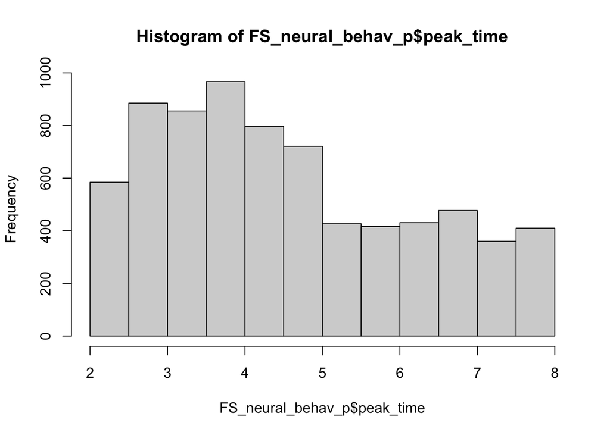

```r
hist(FS_neural_behav_p$peak_time)
```

Gosh yes–that is quite wide and might explain why we get more sensitive results here. I wonder what would happen if we constrained it a bit more to use only peaks at the 2-5 mark.